# HAR

Steffen Hess

10/24/2014

# Analysis

## Loading data

Loading the data and splitting it to experiment on the model

## Reducing sparse variables

Some columns are sparsely populated and hence a bad predictors for out of sample questions. Getting rid of all sparsely populated columns:

```r
mask <- is.na(mytrain)
clM<-colMeans(mask)
thres <- min(clM[clM>0])
ii <- (colMeans(mask) < thres)
mytrain_red <- mytrain[,ii]
summary(ii) ### 60 columns remaining
```

```
##    Mode   FALSE    TRUE    NA's
## logical     100      60       0
```

Only 60 columns are reliably populated

## Omitting sample specific variables

Some variables such as row number `X`, time, `user_name` are specific to the sample and not helpful for predictions

```r
drop <-  c("X","user_name","raw_timestamp_part_1","raw_timestamp_part_2","cvtd_timestamp" ,"new_window","num_window")
mytrain_red2 <- mytrain_red[,!(names(mytrain_red) %in% drop)]
dim(mytrain_red2)
```

```
## [1] 13733    53
```

Reduced dimensions.

## Exploratory models

### First try

Fitting what we have:

```r
rfr2<-randomForest(classe ~ .,data=mytrain_red2)
print(rfr2)
```

```
##
## Call:
##  randomForest(formula = classe ~ ., data = mytrain_red2)
##                Type of random forest: classification
##                      Number of trees: 500
## No. of variables tried at each split: 7
##
##         OOB estimate of  error rate: 0.55%
## Confusion matrix:
##      A    B    C    D    E class.error
## A 3902    3    1    0    0 0.001024066
## B   14 2638    5    0    0 0.007150922
## C    0   14 2379    2    0 0.006680585
## D    0    0   27 2222    2 0.012883163
## E    0    0    1    7 2516 0.003169572
```

Let’s see if we can reduce the number of predictors to reduce bias and prevent overfitting.

### Reduced model

```r
#library(caret)
imp <- varImp(rfr2)
summary(imp)
```

```
##     Overall
##  Min.   : 42.45
##  1st Qu.: 95.17
##  Median :164.27
##  Mean   :208.77
##  3rd Qu.:248.76
##  Max.   :846.40
```

```r
ii<-imp<95.4
names(mytrain_red2[,ii])
```

```
##  [1] "gyros_belt_x"        "gyros_belt_y"        "accel_belt_x"
##  [4] "accel_belt_y"        "total_accel_arm"     "gyros_arm_z"
##  [7] "accel_arm_z"         "gyros_dumbbell_x"    "gyros_dumbbell_z"
## [10] "total_accel_forearm" "gyros_forearm_x"     "gyros_forearm_y"
## [13] "gyros_forearm_z"
```

There seems to be many of the 3D data among the least important predictors. The magnitude of the effects is also in the data, so the 3D data might be less important.

```r
drp <- c(drop,names(mytrain_red[grepl('_x',names(mytrain_red))]))
drp <- c(drp,names(mytrain_red[grepl('_y',names(mytrain_red))]))
drp <- c(drp,names(mytrain_red[grepl('_z',names(mytrain_red))]))
mytrain_red4 <- mytrain_red[,!(names(mytrain_red) %in% drp)]
dim(mytrain_red4)
```

```
## [1] 13733    17
```

reduced dimensions to 17. Now using the Random forest of the ‘caret package’ because it tries multiple values for several of the key model parameters and performs a more elaborate form of cross-validation. Furthermore computing an out of sample error:

```r
modelrf4 <- train(classe ~ ., method='rf',data=mytrain_red4)
#modelrf4 <- randomForest(classe ~ .,data=mytrain_red4)

prd<-predict(modelrf4,mytest)
cm<-confusionMatrix(prd,mytest$classe)
cm
```

```
## Confusion Matrix and Statistics
##
##           Reference
## Prediction    A    B    C    D    E
##          A 1668   14    0    0    2
##          B    6 1109   10    0    4
##          C    0   16 1009    6    2
##          D    0    1    8  959    3
##          E    0    0    0    0 1072
##
## Overall Statistics
##
##                Accuracy : 0.9878
##                  95% CI : (0.9846, 0.9904)
##     No Information Rate : 0.2843
##     P-Value [Acc > NIR] : < 2.2e-16
##
##                   Kappa : 0.9845
##  Mcnemar's Test P-Value : NA
##
## Statistics by Class:
##
##                      Class: A Class: B Class: C Class: D Class: E
## Sensitivity            0.9964   0.9728   0.9825   0.9938   0.9898
## Specificity            0.9962   0.9958   0.9951   0.9976   1.0000
## Pos Pred Value         0.9905   0.9823   0.9768   0.9876   1.0000
## Neg Pred Value         0.9986   0.9935   0.9963   0.9988   0.9977
## Prevalence             0.2843   0.1936   0.1744   0.1639   0.1839
## Detection Rate         0.2832   0.1883   0.1713   0.1628   0.1820
## Detection Prevalence   0.2860   0.1917   0.1754   0.1649   0.1820
## Balanced Accuracy      0.9963   0.9843   0.9888   0.9957   0.9949
```

and plotting the confusion matrix with a log-colorscale:

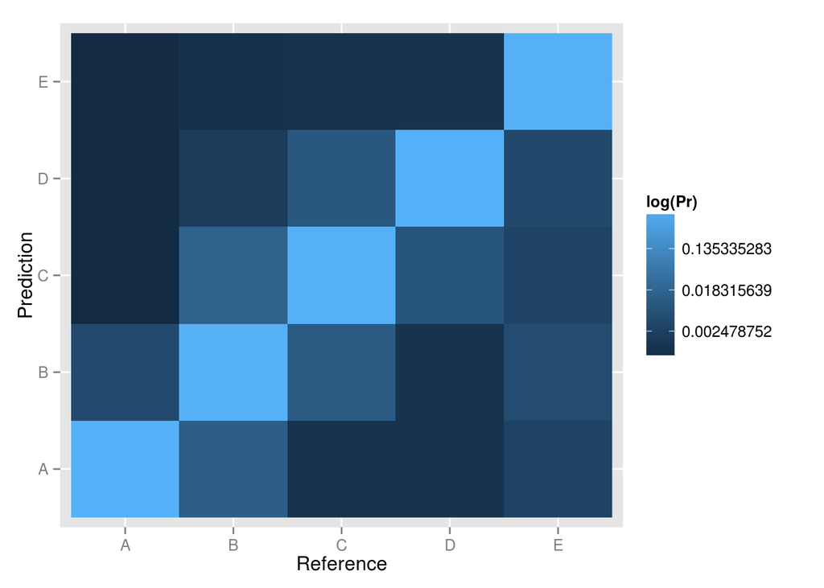

## Predicting on the test sample

Using this model to predict the testing set

```r
predict(modelrf4,testing)
```

```
##  [1] B A B A A E D B A A B C B A E E A B B B
## Levels: A B C D E
```